# Midterm

Yan Liu

2022-02-13

# Midterm (Due Sunday 2/13/2022 at 11:55 pm)

Please submit your `.Rmd` and `.html` files in Sakai. If you are working together, both people should submit the files.

## 60 / 60 points total

The goal of the midterm project is to showcase skills that you have learned in class so far. The midterm is open note, but if you use someone else’s code, you **must attribute them**.

## Instructions: Before you get Started

1. Pick a dataset. Ideally, the dataset should be around 2000 rows, and should have both categorical and numeric covariates. Choose a dataset with more than 4 columns/variables.
- Potential Sources for data: Tidy Tuesday: https://github.com/rfordatascience/tidytuesday.
- See other data sources in the `#data` channel on Slack.
- Note that most of the Tidy Tuesday data are .csv files. There is code to load the files from csv for each of the datasets and a short description of the variables, or you can upload the `.csv` file into your `data` folder.
- You may use another dataset or your own data, but please make sure it is de-identified.
2. Define a research question, involving at least one categorical variable. You may schedule a time with Jessica or Colin to discuss your dataset and research question, or you may message it to one of us in slack or email. Please do one of the two options pretty early on. We just want to look at the data and make sure that it is appropriate for your question.
3. You must use each of the following functions at least once:
- `mutate()`
- `group_by()`
- `summarize()`
- `ggplot()`

and *at least one* of the following:

- `case_when()`
- `across()`
- `*_join()` (i.e. `left_join()`)
- `pivot_*()` (i.e. `pivot_longer()`)
4. The code chunks below are guides, please add more code chunks to do what you need.
5. If you do not want your final project posted on the public website, please let Jessica know. We can also keep it anonymous if you’d like to remove your name from the Rmd and html, or use a pseudonym.

*You may remove these instructions from your final Rmd if you like*

## Working Together

If you’d like to work together, that is encouraged, but you must divide the work equitably and you must note who worked on what. This is probably easiest as notes in the text. Please let Colin or Jessica know that you’ll be working together.

No acknowledgements of contributions = -10 points overall.

## Please Note

I will take off points (-5 points for each section) if you don’t add observations and notes in your RMarkdown document. I want you to think and reason through your analysis, even if they are preliminary thoughts.

## Define Your Research Question (10 points)

> *Define your research question below. What about the data interests you? What is a specific question you want to find out about the data?*  
> The salary survey comes from Ask a Manager. The readers were self-selected to respond to the study in May 2021. It has 26232 observations and 18 variables. I want to focus on the observations from the United States. We generally know working women are paid less than working men. My question is how do age, race, experience years in the field, and education affect the gender pay gap?

> *Given your question, what is your expectation about the data?*  
> The data may show a positive, negative, or no association of gender pay gap by age, race, experience work years in the field, and education. Intuitively， the gender pay cap increases by age, decreases by experience years in the field and education, and may not change much by race.

## Loading the Data (10 points)

> *Load the data below and use `dplyr::glimpse()` or `skimr::skim()` on the data. You should upload the data file into the `data` directory.*

```r
survey <- readr::read_csv('https://raw.githubusercontent.com/rfordatascience/tidytuesday/master/data/2021/2021-05-18/survey.csv')
glimpse(survey)
```

```
## Rows: 26,232
## Columns: 18
## $ timestamp                                <chr> "4/27/2021 11:02:10", "4/27/2…
## $ how_old_are_you                          <chr> "25-34", "25-34", "25-34", "2…
## $ industry                                 <chr> "Education (Higher Education)…
## $ job_title                                <chr> "Research and Instruction Lib…
## $ additional_context_on_job_title          <chr> NA, NA, NA, NA, NA, NA, NA, "…
## $ annual_salary                            <dbl> 55000, 54600, 34000, 62000, 6…
## $ other_monetary_comp                      <dbl> 0, 4000, NA, 3000, 7000, NA, …
## $ currency                                 <chr> "USD", "GBP", "USD", "USD", "…
## $ currency_other                           <chr> NA, NA, NA, NA, NA, NA, NA, N…
## $ additional_context_on_income             <chr> NA, NA, NA, NA, NA, NA, NA, N…
## $ country                                  <chr> "United States", "United King…
## $ state                                    <chr> "Massachusetts", NA, "Tenness…
## $ city                                     <chr> "Boston", "Cambridge", "Chatt…
## $ overall_years_of_professional_experience <chr> "5-7 years", "8 - 10 years", …
## $ years_of_experience_in_field             <chr> "5-7 years", "5-7 years", "2 …
## $ highest_level_of_education_completed     <chr> "Master's degree", "College d…
## $ gender                                   <chr> "Woman", "Non-binary", "Woman…
## $ race                                     <chr> "White", "White", "White", "W…
```

> *If there are any quirks that you have to deal with `NA` coded as something else, or it is multiple tables, please make some notes here about what you need to do before you start transforming the data in the next section.*

First, I will select the United States’ data according to my focus. Second, I will rename and deal with NA and other unclear data to clarify the categorical data with different levels.

> **Make sure your data types are correct!**

## Transforming the data (15 points)

> *If the data needs to be transformed in any way (values recoded, pivoted, etc), do it here. Examples include transforming a continuous variable into a categorical using `case_when()`, etc.*

```r
# select data of United States
survey1<-survey%>%filter(country=="United States"|country=="america"|country=="America"|country=="US"|country=="USA")

# rename the column, deal with NA and other unclear data
survey2<-survey1%>%
  rename(age=how_old_are_you,
         experyr=years_of_experience_in_field,
         edu=highest_level_of_education_completed)%>%
  separate(col = race,
           into = c("race1", "race2"),
           sep = ",") %>%
   mutate(id=1:19434,
          race1=na_if(race1,"Another option not listed here or prefer not to answer"),
          race1=str_replace_all(race1,"Hispanic","Hispanic, Latino, or Spanish origin"),
          gender1=na_if(gender,"Other or prefer not to answer"),
          gender1=na_if(gender1,"Prefer not to answer"),
          gender1=na_if(gender1,"Non-binary"),
          experyr1 =str_remove_all(experyr, "years"))
# Convert type of categorical variables to factor, select variables we need to see the levels
survey3<-as.data.frame(unclass(survey2),
                       stringsAsFactors = TRUE)%>%
  select(id,annual_salary,gender1,race1,age,experyr1,edu)

survey3%>%summarise(across(c(age,race1,gender1,experyr1,edu),
                   .fns = ~ str_flatten(sort(unique(.x)),collapse = "/"))) %>%
  t() %>%
  as_tibble(rownames = "var") %>%
  gt()
```

| var | V1 |
| --- | --- |
| age | 18-24/25-34/35-44/45-54/55-64/65 or over/under 18 |
| race1 | Asian or Asian American/Black or African American/Hispanic, Latino, or Spanish origin/Middle Eastern or Northern African/Native American or Alaska Native/White |
| gender1 | Man/Woman |
| experyr1 | 1 year or less/11 - 20 /2 - 4 /21 - 30 /31 - 40 /41 or more/5-7 /8 - 10 |
| edu | College degree/High School/Master's degree/PhD/Professional degree (MD, JD, etc.)/Some college |

> *Bonus points (5 points) for datasets that require merging of tables, but only if you reason through whether you should use `left_join`, `inner_join`, or `right_join` on these tables. No credit will be provided if you don’t.*

I choose some variables from survey2 and create survey11,survey12. I use left_join since the left one with variables about general information about observations and the right one with variables about the career. (To Midterm project, I don’t need to join. But this step may help to be familiar with join function and be useful to further study)

```r
#join function
names(survey2)
```

```
##  [1] "timestamp"
##  [2] "age"
##  [3] "industry"
##  [4] "job_title"
##  [5] "additional_context_on_job_title"
##  [6] "annual_salary"
##  [7] "other_monetary_comp"
##  [8] "currency"
##  [9] "currency_other"
## [10] "additional_context_on_income"
## [11] "country"
## [12] "state"
## [13] "city"
## [14] "overall_years_of_professional_experience"
## [15] "experyr"
## [16] "edu"
## [17] "gender"
## [18] "race1"
## [19] "race2"
## [20] "id"
## [21] "gender1"
## [22] "experyr1"
```

```r
survey11<-survey2%>%select(id,age,gender,race1,edu,country,state)
survey12<-survey2%>%select(id,annual_salary,other_monetary_comp,industry,job_title,experyr)
survey_new<-left_join(survey11,survey12,by=c("id"="id"))
glimpse(survey_new)
```

```
## Rows: 19,434
## Columns: 12
## $ id                  <int> 1, 2, 3, 4, 5, 6, 7, 8, 9, 10, 11, 12, 13, 14, 15,…
## $ age                 <chr> "25-34", "25-34", "25-34", "25-34", "25-34", "25-3…
## $ gender              <chr> "Woman", "Woman", "Woman", "Woman", "Man", "Woman"…
## $ race1               <chr> "White", "White", "White", "White", "White", "Whit…
## $ edu                 <chr> "Master's degree", "College degree", "College degr…
## $ country             <chr> "United States", "US", "USA", "US", "USA", "USA", …
## $ state               <chr> "Massachusetts", "Tennessee", "Wisconsin", "South …
## $ annual_salary       <dbl> 55000, 34000, 62000, 60000, 62000, 33000, 50000, 1…
## $ other_monetary_comp <dbl> 0, NA, 3000, 7000, NA, 2000, NA, 10000, 0, 0, 0, 0…
## $ industry            <chr> "Education (Higher Education)", "Accounting, Banki…
## $ job_title           <chr> "Research and Instruction Librarian", "Marketing S…
## $ experyr             <chr> "5-7 years", "2 - 4 years", "5-7 years", "5-7 year…
```

> *Show your transformed table here.* Use tools such as `glimpse()`, `skim()` or `head()` to illustrate your point.

```r
# overlook data
glimpse(survey3)
```

```
## Rows: 19,434
## Columns: 7
## $ id            <int> 1, 2, 3, 4, 5, 6, 7, 8, 9, 10, 11, 12, 13, 14, 15, 16, 1…
## $ annual_salary <dbl> 55000, 34000, 62000, 60000, 62000, 33000, 50000, 112000,…
## $ gender1       <fct> Woman, Woman, Woman, Woman, Man, Woman, Man, Woman, Woma…
## $ race1         <fct> "White", "White", "White", "White", "White", "White", "W…
## $ age           <fct> 25-34, 25-34, 25-34, 25-34, 25-34, 25-34, 25-34, 45-54, …
## $ experyr1      <fct> 5-7 , 2 - 4 , 5-7 , 5-7 , 2 - 4 , 2 - 4 , 5-7 , 21 - 30 …
## $ edu           <fct> "Master's degree", "College degree", "College degree", "…
```

```r
skim(survey3)
```

Data summary

| Name | survey3 |
| --- | --- |
| Number of rows | 19434 |
| Number of columns | 7 |
| _______________________ |  |
| Column type frequency: |  |
| factor | 5 |
| numeric | 2 |
| ________________________ |  |
| Group variables | None |

**Variable type: factor**

| skim_variable | n_missing | complete_rate | ordered | n_unique | top_counts |
| --- | --- | --- | --- | --- | --- |
| gender1 | 814 | 0.96 | FALSE | 2 | Wom: 15366, Man: 3254 |
| race1 | 470 | 0.98 | FALSE | 6 | Whi: 16280, Asi: 1161, His: 726, Bla: 626 |
| age | 0 | 1.00 | FALSE | 7 | 25-: 8585, 35-: 7032, 45-: 2279, 18-: 735 |
| experyr1 | 0 | 1.00 | FALSE | 8 | 11 : 4674, 5-7: 4572, 2 -: 4094, 8 -: 3554 |
| edu | 123 | 0.99 | FALSE | 6 | Col: 9386, Mas: 6370, Som: 1315, Pro: 977 |

**Variable type: numeric**

| skim_variable | n_missing | complete_rate | mean | sd | p0 | p25 | p50 | p75 | p100 | hist |
| --- | --- | --- | --- | --- | --- | --- | --- | --- | --- | --- |
| id | 0 | 1 | 9717.5 | 5610.26 | 1 | 4859.25 | 9717.5 | 14575.75 | 19434 | ▇▇▇▇▇ |
| annual_salary | 0 | 1 | 92379.2 | 68780.11 | 0 | 57000.00 | 79000.0 | 112380.00 | 3600000 | ▇▁▁▁▁ |

```r
head(survey3,10)
```

```
##    id annual_salary gender1                               race1   age experyr1
## 1   1         55000   Woman                               White 25-34     5-7
## 2   2         34000   Woman                               White 25-34   2 - 4
## 3   3         62000   Woman                               White 25-34     5-7
## 4   4         60000   Woman                               White 25-34     5-7
## 5   5         62000     Man                               White 25-34   2 - 4
## 6   6         33000   Woman                               White 25-34   2 - 4
## 7   7         50000     Man                               White 25-34     5-7
## 8   8        112000   Woman                               White 45-54 21 - 30
## 9   9         45000   Woman Hispanic, Latino, or Spanish origin 35-44 21 - 30
## 10 10         47500   Woman                               White 25-34     5-7
##                edu
## 1  Master's degree
## 2   College degree
## 3   College degree
## 4   College degree
## 5  Master's degree
## 6   College degree
## 7  Master's degree
## 8   College degree
## 9   College degree
## 10  College degree
```

> *Are the values what you expected for the variables? Why or Why not?*

Most of the values are my expectations. There are six variables in total. The annual salary is numerical, and the others are categorical. I hope age and experience years are numerical since I can use a linear model to analyze the relationship.

## Visualizing and Summarizing the Data (15 points)

> *Use `group_by()` and `summarize()` to make a summary of the data here. The summary should be relevant to your research question*

```r
gender_all<-survey3%>%group_by(gender1)%>%
  summarize(average_annual_salary = mean(annual_salary,na.rm=TRUE),
            median_annual_salary=median(annual_salary,na.rm=TRUE))%>%
  na.omit()
gender_all
```

```
## # A tibble: 2 × 3
##   gender1 average_annual_salary median_annual_salary
##   <fct>                   <dbl>                <dbl>
## 1 Man                   118701.               105000
## 2 Woman                  87056.                75000
```

```r
gender_all%>%summarize(diff_mean=diff(average_annual_salary),diff_median=diff(median_annual_salary))
```

```
## # A tibble: 1 × 2
##   diff_mean diff_median
##       <dbl>       <dbl>
## 1   -31645.      -30000
```

```r
gender_race<-survey3%>%group_by(race1,gender1)%>%
  summarize(average_annual_salary = mean(annual_salary, na.rm = TRUE),
            median_annual_salary=median(annual_salary, na.rm = TRUE))%>%
  na.omit()
gender_race
```

```
## # A tibble: 12 × 4
## # Groups:   race1 [6]
##    race1                               gender1 average_annual_… median_annual_s…
##    <fct>                               <fct>              <dbl>            <dbl>
##  1 Asian or Asian American             Man              137141.           117851
##  2 Asian or Asian American             Woman            101278.            90000
##  3 Black or African American           Man              109217.            98214
##  4 Black or African American           Woman             92291.            76000
##  5 Hispanic, Latino, or Spanish origin Man              102999.            90000
##  6 Hispanic, Latino, or Spanish origin Woman             83332.            74000
##  7 Middle Eastern or Northern African  Man              129438.           136000
##  8 Middle Eastern or Northern African  Woman             91504.            75000
##  9 Native American or Alaska Native    Man              121721.           110800
## 10 Native American or Alaska Native    Woman             79597.            73000
## 11 White                               Man              118203.           105000
## 12 White                               Woman             85781.            75000
```

```r
gender_race%>%group_by(race1)%>%summarize(diff_mean=diff(average_annual_salary),diff_median=diff(median_annual_salary))%>%arrange(diff_mean)
```

```
## # A tibble: 6 × 3
##   race1                               diff_mean diff_median
##   <fct>                                   <dbl>       <dbl>
## 1 Native American or Alaska Native      -42124.      -37800
## 2 Middle Eastern or Northern African    -37933.      -61000
## 3 Asian or Asian American               -35864.      -27851
## 4 White                                 -32422.      -30000
## 5 Hispanic, Latino, or Spanish origin   -19667.      -16000
## 6 Black or African American             -16926.      -22214
```

```r
gender_edu<-survey3%>%group_by(edu,gender1)%>%
  summarize(average_annual_salary = mean(annual_salary, na.rm = TRUE),
            median_annual_salary=median(annual_salary, na.rm = TRUE))%>%
  na.omit()
gender_edu
```

```
## # A tibble: 12 × 4
## # Groups:   edu [6]
##    edu                                gender1 average_annual_s… median_annual_s…
##    <fct>                              <fct>               <dbl>            <dbl>
##  1 College degree                     Man               114860.           100000
##  2 College degree                     Woman              81569.            72000
##  3 High School                        Man               109547.           100003
##  4 High School                        Woman              57634.            50250
##  5 Master's degree                    Man               119138.           105000
##  6 Master's degree                    Woman              88192.            78000
##  7 PhD                                Man               143421.           136500
##  8 PhD                                Woman             103430.            91000
##  9 Professional degree (MD, JD, etc.) Man               165224.           133500
## 10 Professional degree (MD, JD, etc.) Woman             138389.           115000
## 11 Some college                       Man               109568.            96000
## 12 Some college                       Woman              69337.            60000
```

```r
gender_edu%>%group_by(edu)%>%summarize(diff_mean=diff(average_annual_salary),diff_median=diff(median_annual_salary))%>%arrange(diff_mean)
```

```
## # A tibble: 6 × 3
##   edu                                diff_mean diff_median
##   <fct>                                  <dbl>       <dbl>
## 1 High School                          -51913.      -49753
## 2 Some college                         -40231.      -36000
## 3 PhD                                  -39992.      -45500
## 4 College degree                       -33291.      -28000
## 5 Master's degree                      -30946.      -27000
## 6 Professional degree (MD, JD, etc.)   -26835.      -18500
```

```r
gender_exper<-survey3%>%group_by(experyr1,gender1)%>%
  summarize(average_annual_salary = mean(annual_salary, na.rm = TRUE),
            median_annual_salary=median(annual_salary, na.rm = TRUE))%>%
  na.omit()
gender_exper
```

```
## # A tibble: 16 × 4
## # Groups:   experyr1 [8]
##    experyr1         gender1 average_annual_salary median_annual_salary
##    <fct>            <fct>                   <dbl>                <dbl>
##  1 "1 year or less" Man                    70673.               60138.
##  2 "1 year or less" Woman                  65061.               56000
##  3 "11 - 20 "       Man                   135344.              129400
##  4 "11 - 20 "       Woman                  99284.               89000
##  5 "2 - 4 "         Man                    88835.               75000
##  6 "2 - 4 "         Woman                  71680.               62646.
##  7 "21 - 30 "       Man                   154034.              145500
##  8 "21 - 30 "       Woman                 109906.               94000
##  9 "31 - 40 "       Man                   140926.              131000
## 10 "31 - 40 "       Woman                 106731.               95663
## 11 "41  or more"    Man                   137273.              121000
## 12 "41  or more"    Woman                  89706.               95000
## 13 "5-7 "           Man                   107066.               91000
## 14 "5-7 "           Woman                  82403.               72000
## 15 "8 - 10 "        Man                   118211.              106871
## 16 "8 - 10 "        Woman                  91599.               80000
```

```r
gender_exper%>%group_by(experyr1)%>%summarize(diff_mean=diff(average_annual_salary),diff_median=diff(median_annual_salary))%>%arrange(diff_mean)
```

```
## # A tibble: 8 × 3
##   experyr1         diff_mean diff_median
##   <fct>                <dbl>       <dbl>
## 1 "41  or more"      -47567.     -26000
## 2 "21 - 30 "         -44128.     -51500
## 3 "11 - 20 "         -36060.     -40400
## 4 "31 - 40 "         -34195.     -35337
## 5 "8 - 10 "          -26612.     -26871
## 6 "5-7 "             -24663.     -19000
## 7 "2 - 4 "           -17155.     -12354.
## 8 "1 year or less"    -5612.      -4138.
```

```r
gender_age<-survey3%>%group_by(age,gender1)%>%
  summarize(average_annual_salary = mean(annual_salary, na.rm = TRUE),
            median_annual_salary=median(annual_salary, na.rm = TRUE))%>%
  na.omit()
gender_age
```

```
## # A tibble: 13 × 4
## # Groups:   age [7]
##    age        gender1 average_annual_salary median_annual_salary
##    <fct>      <fct>                   <dbl>                <dbl>
##  1 18-24      Man                    66184.                60875
##  2 18-24      Woman                  62114.                54000
##  3 25-34      Man                   106680.                90000
##  4 25-34      Woman                  81440.                70000
##  5 35-44      Man                   126959.               117000
##  6 35-44      Woman                  93526.                82000
##  7 45-54      Man                   136893.               128000
##  8 45-54      Woman                  94246.                84300
##  9 55-64      Man                   132030.               123000
## 10 55-64      Woman                  93755.                78000
## 11 65 or over Man                   121452.               117000
## 12 65 or over Woman                  98271.                90000
## 13 under 18   Woman                  72453.                72600
```

```r
gender_age%>%group_by(age)%>%summarize(diff_mean=diff(average_annual_salary),diff_median=diff(median_annual_salary))%>%arrange(diff_mean)
```

```
## # A tibble: 6 × 3
## # Groups:   age [6]
##   age        diff_mean diff_median
##   <fct>          <dbl>       <dbl>
## 1 45-54        -42647.      -43700
## 2 55-64        -38275.      -45000
## 3 35-44        -33433.      -35000
## 4 25-34        -25240.      -20000
## 5 65 or over   -23181.      -27000
## 6 18-24         -4070.       -6875
```

> *What are your findings about the summary? Are they what you expected?*

From the summary, I get the mean and median annual salary between women and men by age, education, experience years in the field and race, and also get the mean and median gender pay gap by by age, education, experience years in the field and race.

Yes, the summary gave me all the values I needed.

> *Make at least two plots that help you answer your question on the transformed or summarized data. Use scales and/or labels to make each plot informative.*

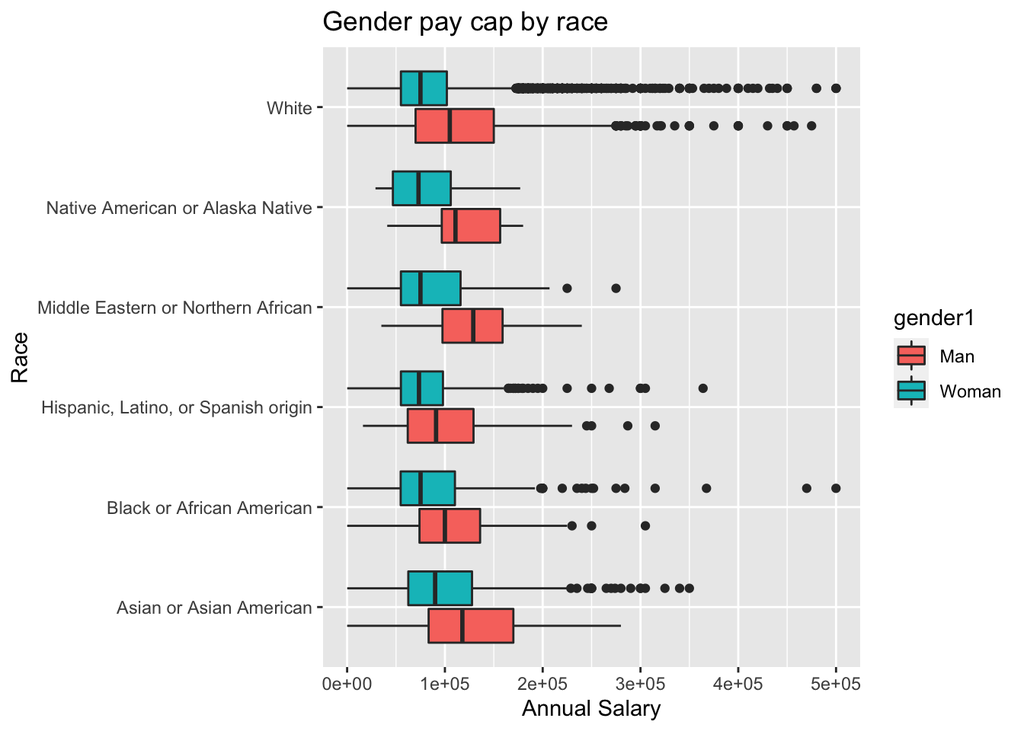

```r
ggplot(data=na.omit(survey3),aes(y=race1, x=annual_salary,fill=gender1))+
  geom_boxplot() +xlim(0,500000)+
  labs(title = "Gender pay cap by race",
       y = "Race",
       x = "Annual Salary")
```

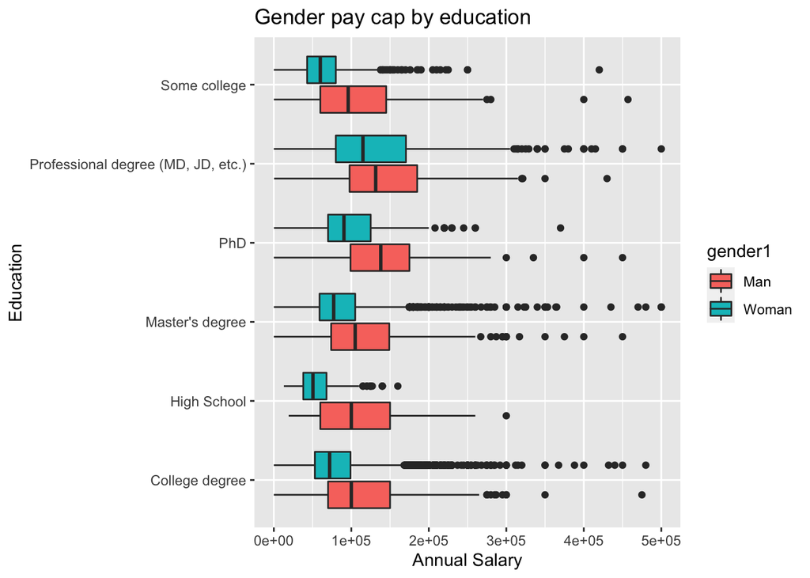

```r
ggplot(data=na.omit(survey3),aes(y=edu, x=annual_salary,fill=gender1))+
  geom_boxplot() +xlim(0,500000)+
  labs(title = "Gender pay cap by education",
       y = "Education",
       x = "Annual Salary")
```

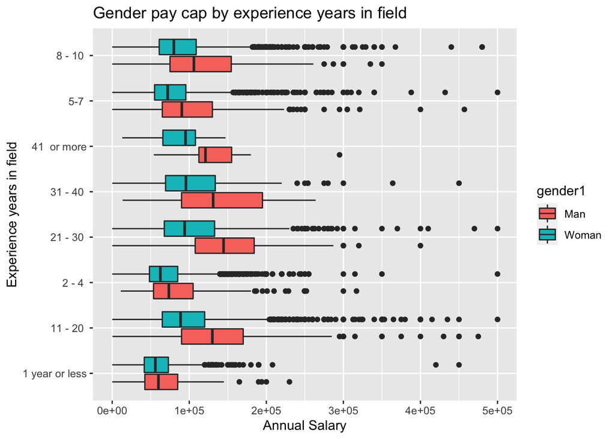

```r
ggplot(data=na.omit(survey3),aes(y=experyr1, x=annual_salary,fill=gender1))+
  geom_boxplot() +xlim(0,500000)+
  labs(title = "Gender pay cap by experience years in field",
       y = "Experience years in field",
       x = "Annual Salary")
```

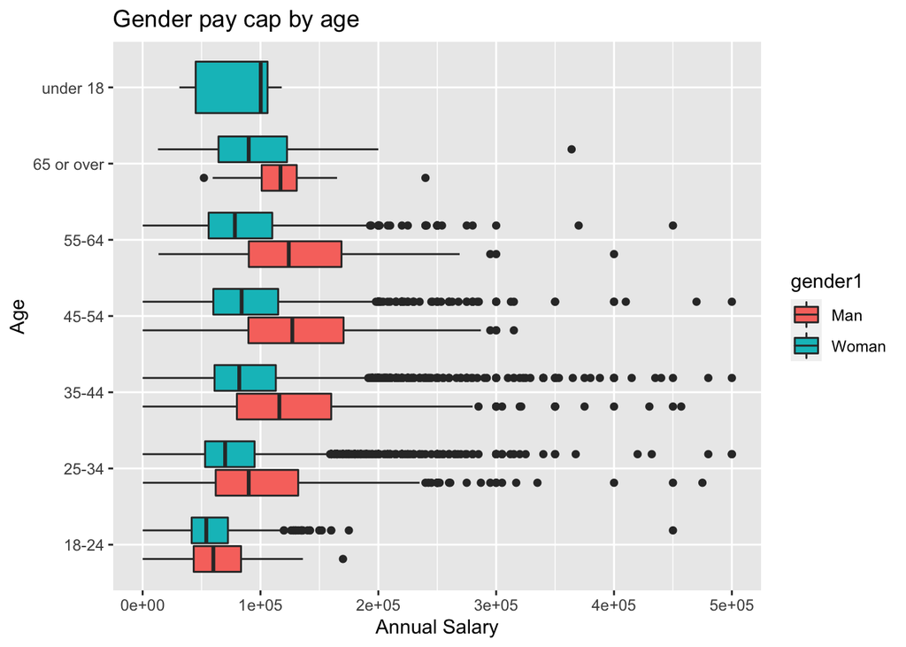

```r
ggplot(data=na.omit(survey3),aes(y=age, x=annual_salary,fill=gender1))+
  geom_boxplot() +xlim(0,500000)+
  labs(title = "Gender pay cap by age",
       y = "Age",
       x = "Annual Salary")
```

## Final Summary (10 points)

> *Summarize your research question and findings below.*

Accurate salary data is essential for people to know their situation in the salary market. As a graduate student in Biostatistics, I particularly care about women in the salary market.

According to the data from the ask a manager survey, I analyze annual income, gender, age, race, education, experience years in the field.

> *Are your findings what you expected? Why or Why not?*

The results are not much like my expectation. As the report from DOL, women earn 82% of men. However, the gap in this survey is 73%. The gender pay gap has not narrowed but enlarged from the mean gender pay gap by age and experience years in the field. And gender pay gap by education shows that the smallest gap is in professional education; the education of Ph.D. enlarges the gap.

To the next exploration, first, I want to find the reason of the results, like why Ph.D. does not narrow the gap?

Second, since I only analyze the gender pay gap by each of age, race, education, experience years in the field. It could be explored more in other variables, like occupations. And it can also have some interesting findings in the gender pay gap by 2-3 variables together, like observations with the master degree, Asian American has more significant gender pay gap than White?

Third, since the data is from the survey and people are self-selected to answer, it is biased and inaccurate. I could explore more than data from DOL or other experiments.